[figure not shown]

1

Ejercicios sugeridos sobre variables aleatorias

discretas

Binomial

Bernoulli

Hiper

geométrica Poisson

Aproximaciones

Discreta

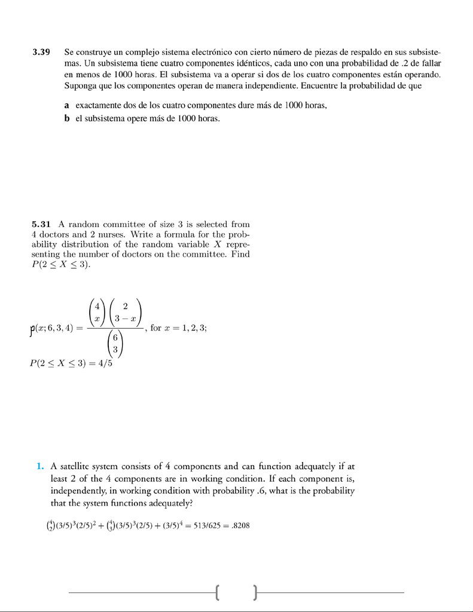

2

Ejercicio 3.39 de Wackerly (2010)

Rta: a: 0.1536; b: 0.9728.

Usando R: dbinom(x=2, size=4, prob=0.2) y sum(dbinom(x=0:2, size=4, prob=0.2))

Ejercicio 5.31 de Walpole (2012)

Rta:

Nota: en este problema la variable X no puede tomar el valor de 0 porque al sacar un comité de 3 siempre vamos

a tener al menos un doctor porque solo hay dos enfermeras.

Usando R: sum(dhyper(x=2:3, 4, 2, 3))

Ejercicio 5.1 de Ross (2014)

Rta:

Usando R: sum(dbinom(x=2:4, size=4, prob=0.6))

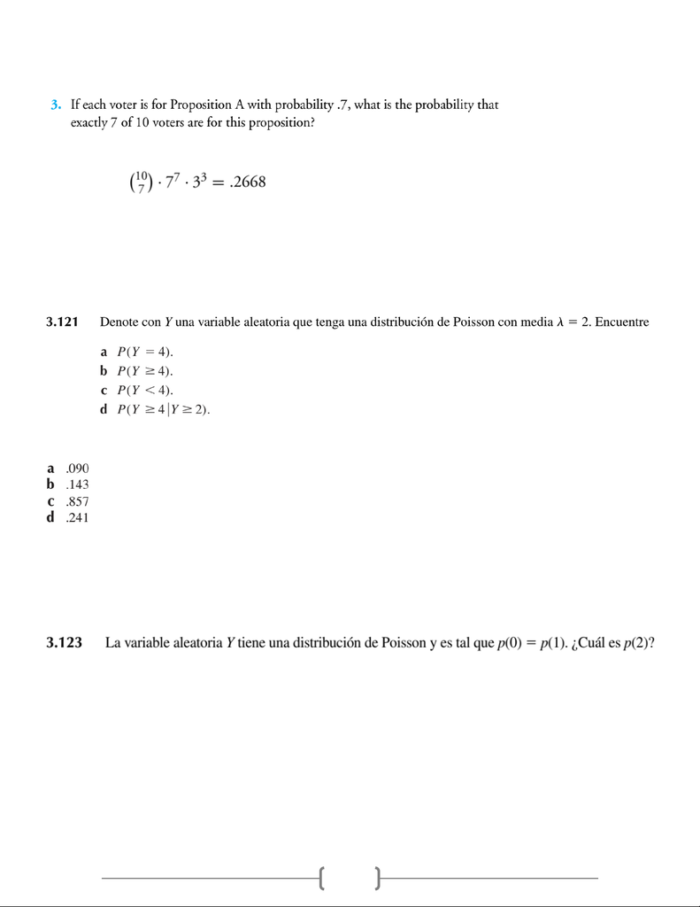

3

Ejercicio 5.3 de Ross (2014),

Rta:

Manualmente:

Usando R: dbinom(x=7, size=10, prob=0.7)

Ejercicio 3.121 de Wackerly (2010)

Rta:

Usando R: dpois(x=4, lambda=2); 1 - ppois(q=3, lambda=2); ppois(q=3, lambda=2); mejor hacerla manual para

entender.

Ejercicio 3.123 de Wackerly (2010)

Rta: 0.1839.

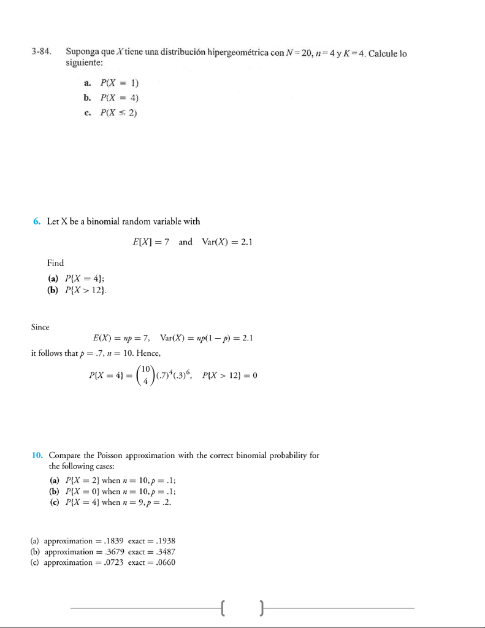

4

Ejercicio 3.84 de Montgomery (1996)

Rta: 0.4623, 0.0002, 0.9866.

Usando R: dhyper(x=1, 4, 16, 4); dhyper(x=4, 4, 16, 4); phyper(q=2, 4, 16, 4)

Ejercicio 5.6 de Ross (2014).

Rta:

Ejercicio 5.10 de Ross (2014)

Rta:

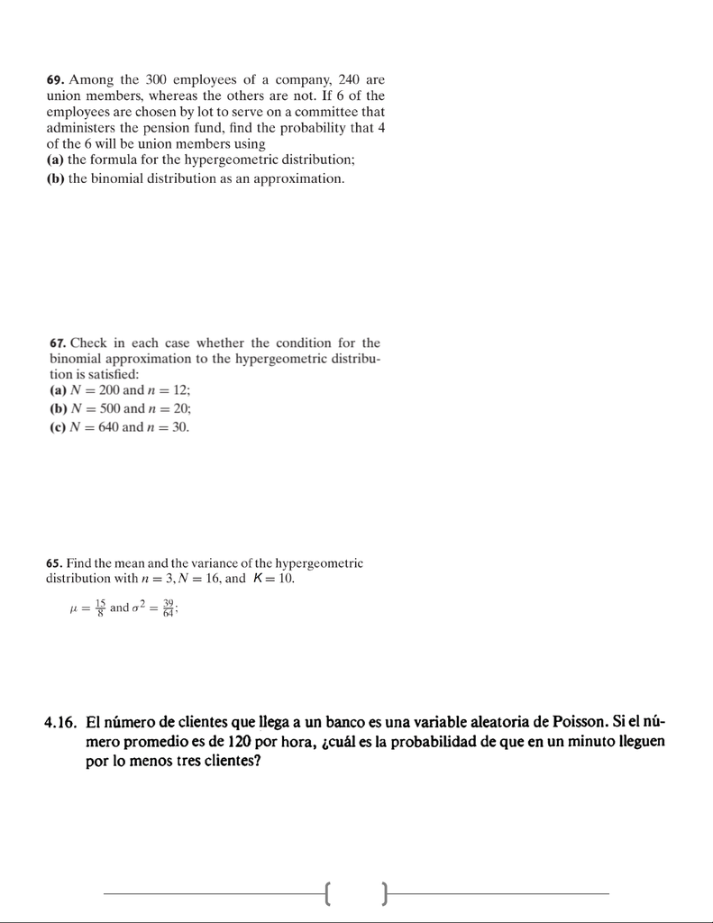

5

Ejercicio 69 pag 174 de Freund et. Al (2014)

Rta: (a) 0.2478; (b) 0.2458.

Usando R: dhyper(x=4, 240, 60, 6); dbinom(x=4, size=6, prob=240/300)

Ejercicio 67 pag 173 de Freund et. Al (2014)

Ejercicio 65 pag 173 de Freund et. Al (2014)

Rta:

Ejercicio 4.16 de Canavos (1998)

Rta: 0.3233

Usando R: 1 – ppois(q=2, lambda=120/60)

[figure not shown]

6

Tabla de organización de los ejercicios sugeridos.

Tema

Ejercicios

Binomial

3.39, 5.1, 5.3, 5.6

Hipergeométrica

5.31, 3.84, 65

Poisson

3.121, 3.123

Aproximaciones

5.10, 69, 67

[figure not shown]

7

Hacer los ejemplos y ejercicios del texto guía: